# Lecture 3: Data Visualization in R

September, 2015

## Quick announcements

Groups are coming

Rune is coming

Mikkel created some cool [plots](https://twitter.com/mikkelkrogsholm/status/641916325376475136/photo/1) using our marijuana data

## Data visualizations in R

`R` has excellent plotting libraries

There is the base plotting function (`plot`) which can be useful once in a while. Furthermore, there is the `lattice` library which is very powerful but has a complicated syntax.

Today we will focus on `ggplot2`, written by Hadley Wickham

I'll show you a lot of examples using some data I downloaded from Facebook. Afterwards, you will work with `ggplot2` in groups

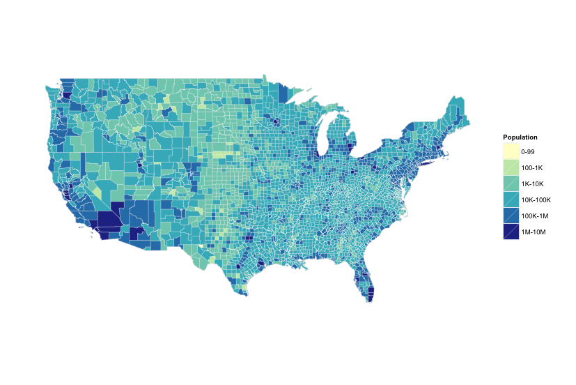

source: [Bob Rudis](https://github.com/hrbrmstr?tab=repositories)

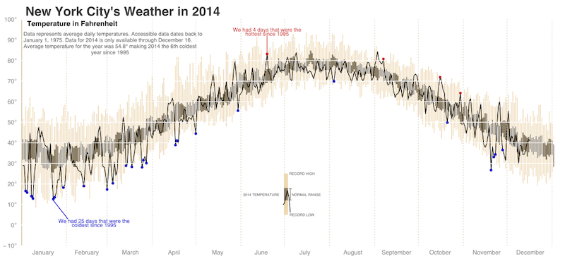

source: [Alex Bresler](https://gist.github.com/abresler/46c36c1a88c849b94b07)

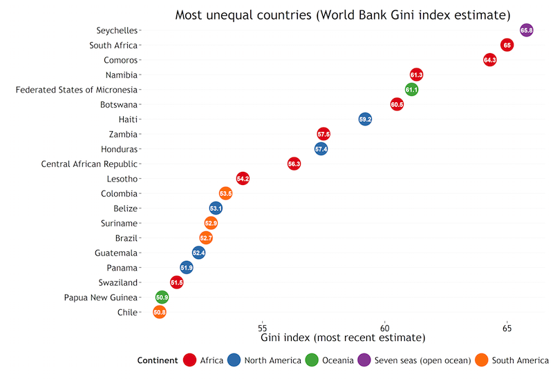

source: [Kyle Walker](http://walkerke.github.io/2015/04/map-or-chart/)

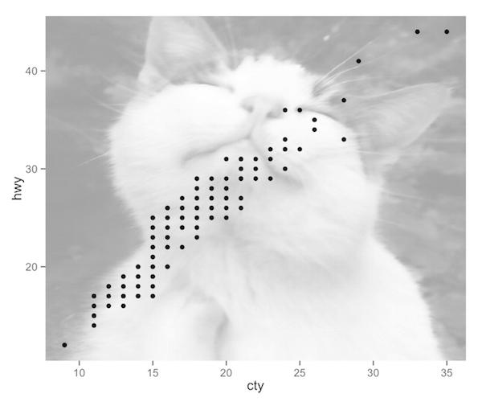

source: [Hillary Parker](https://github.com/hilaryparker/cats)

## `ggplot2` - a grammar of graphics in R

`ggplot2` is based on the grammar of graphics, the idea that you can build every graph from the same few components: a dataset, a set of geoms—visual marks that represent data points, and a coordinate system

> A statistical graph is a mapping from *data* to *aesthetic* attributes (colour, shape, size) of *geometric* objects (points, lines, bars). The plot may also contain *statistical transformations* of the data and is drawn on a specific *coordinate* system. *Faceting* can be used to generate the same plot for different subsets of the dataset. It is the combination of these independent components that make up a graphic.  
> - Wickham, *ggplot2*, p. 3.

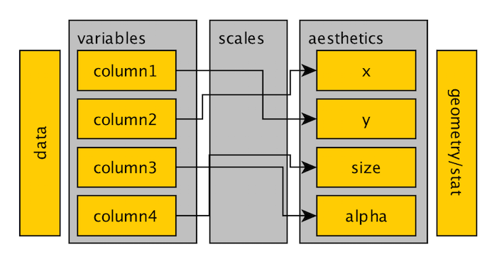

[source](http://stcorp.nl/R_course/tutorial_ggplot2.html)

## Components of a graph

- **data**: What you want to visualize, including variables (columns) to be mapped to aesthetic attributes.
- **geom**: Geometric objects that are drawn to represent the data: bars, lines, points, etc.
- **stats**: Statistical transformations of the data, such as binning or averaging.
- **scales**: Map values in the data space to values in an aesthetic space (color, shape, size…)
- **coord**: Coordinate system; provides axes and gridlines to make it possible to read the graph.
- **facets**: Breaking up the data into subsets, to be displayed independently on a grid.

## Data

We will work with the latest 5,000 Facebook posts from the Danish newspaper Politiken.

The script that downloads the data is on [github](https://github.com/sebastianbarfort/sds/blob/master/scripts/facebook.R).

Read the data

```r
library("readr")

df = read_csv("https://raw.githubusercontent.com/sebastianbarfort/sds/master/data/politiken.csv",
  col_types = list(created_time = col_character()))

df$created_time = parse_datetime(df$created_time)
```

[Link to data](https://raw.githubusercontent.com/sebastianbarfort/sds/master/data/politiken.csv)

## Plotting one (continuous) variable

Distribution of number of likes for each post.

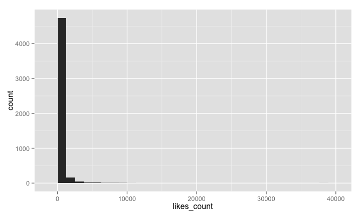

```r
library("ggplot2")
p = ggplot(data = df, aes(x = likes_count)) # data & aesthetics
p + geom_histogram() # add geom
```

## Plotting one (continuous) variable: histogram

Distribution of (logged) number of likes for each post.

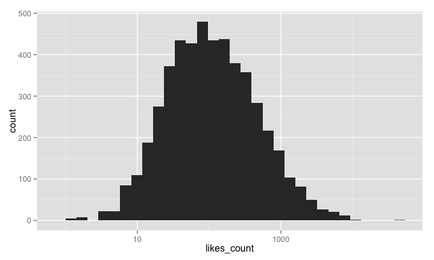

```r
p = ggplot(data = df, aes(x = likes_count)) # data & aesthetics
p = p + geom_histogram() # add geom
p + scale_x_log10() # add log scale
```

## Plotting one (continuous) variable: density plot

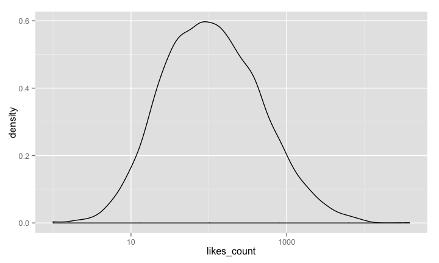

```r
p = ggplot(data = df, aes(x = likes_count)) # data & aesthetics
p = p + geom_density() # add geom
p + scale_x_log10() # add log scale
```

## Plotting one (continuous) variable: area plot

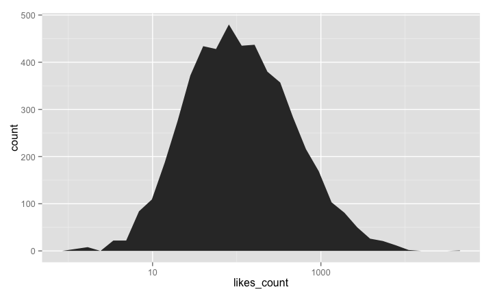

```r
p = ggplot(data = df, aes(x = likes_count)) # data & aesthetics
p = p + geom_area(stat = "bin") # add geom
p + scale_x_log10() # add log scale
```

## Plotting one (continuous) variable: combining geoms

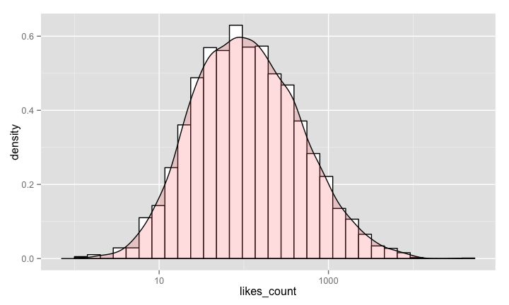

```r
p = ggplot(data = df, aes(x = likes_count)) # data & aesthetics
p + geom_histogram(aes(y=..density..), colour="black", fill="white") +
    geom_density(alpha=.2, fill="#FF6666") + scale_x_log10()
```

## Plotting two (continuous) variables

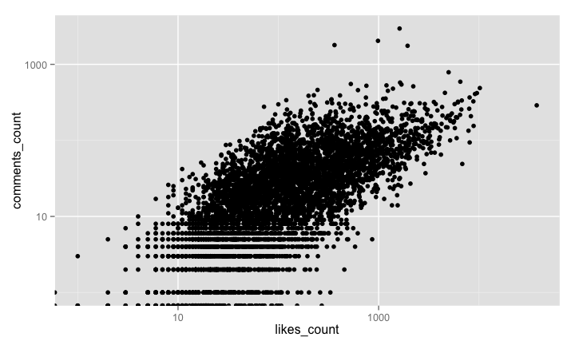

```r
p = ggplot(data = df, aes(x = likes_count, y = comments_count))
p + geom_point() + scale_x_log10() + scale_y_log10() # add log scales
```

## Plotting two (continuous) variables: smoothers

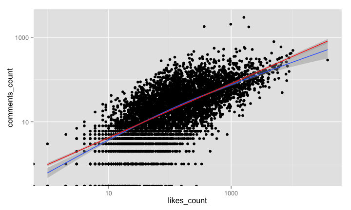

```r
p + geom_point() + geom_smooth(na.rm = TRUE,
  data = df[df$likes_count>0 & df$comments_count>0,]) +
  geom_smooth(na.rm = TRUE,
    data = df[df$likes_count>0 & df$comments_count>0,],
    method = "lm", colour = "red") +
  scale_x_log10() + scale_y_log10() # add log scales
```

## Plotting two (continuous) variables

Number of likes over time

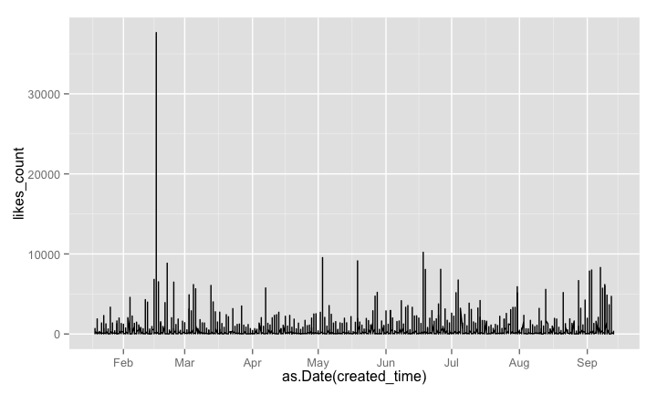

```r
p = ggplot(df, aes(x = as.Date(created_time), y = likes_count))
p + geom_line()
```

## Categorical variables

We can see the section by following the `link` variable in the dataset

```r
head(df$link, 3)
```

```
## [1] "http://politiken.dk/mad/ECE2837880/det-lille-mejeri-er-blevet-stor-industri/"
## [2] "http://politiken.dk/indland/ECE2839489/skoleelever-fodboldboern-og-socialt-udsatte-maa-betale-i-koebenhavn/"
## [3] "http://politiken.dk/sport/ECE2839793/skolepige-skiftede-strutskoert-og-ballet-ud-med-knaldhaarde-tacklinger/"
```

We can grab the section using a regular expression

```r
library("stringr")
df$section = str_extract(df$link, ".dk/[a-z]*")
df$section = gsub(".dk/", "", df$section)
head(df$section, 5)
```

```
## [1] "mad"          "indland"      "sport"        "debat"
## [5] "forbrugogliv"
```

## Discrete X, continuous Y

Count average number of likes by section

```r
library("dplyr")
df.section = df %>%
  filter(!is.na(section)) %>%
  filter(section != "") %>%
group_by(section) %>%
  summarise(
    likes.pr.post = mean(likes_count, na.rm = TRUE)
) %>%
  arrange(-likes.pr.post)
```

## Plot mean likes by section

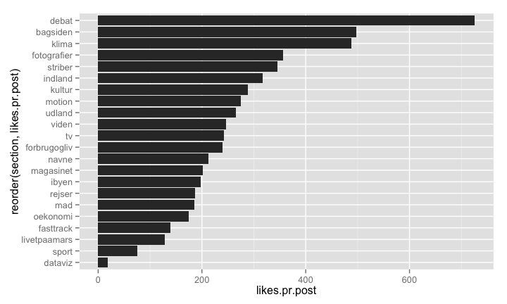

```r
p = ggplot(df.section, aes(x = reorder(section, likes.pr.post),
  y = likes.pr.post))
p + geom_bar(stat = "identity") + coord_flip()
```

## Distribution of likes by weekday

Let's create a variable for the weekday of the post

```r
library("lubridate")
df$weekday = wday(df$created_time, label = TRUE)
```

Let's plot the distribution of likes by weekday

```r
p = ggplot(df, aes(x = likes_count, colour = weekday))
p = p + geom_density() + scale_x_log10()
```

## Result

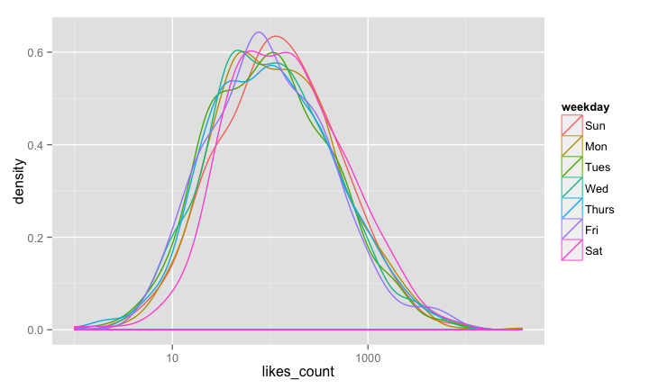

## Two continuous and a categorical variable

Relationship between likes and comments by weekday

```r
p = ggplot(df, aes(x = likes_count, y = comments_count))
p = p + geom_point() + scale_x_log10() + scale_y_log10() +
  geom_smooth(na.rm = TRUE,
    data = df[df$likes_count>0 & df$comments_count>0,]) +
  facet_wrap(~ weekday, scales = "free")
```

## Result

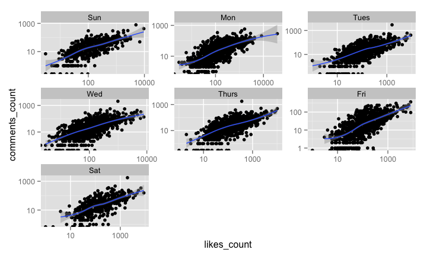

## Two continuous and two categorical variables

Let's compare the `indland` and `udland` parts of Politiken

```r
df.subset = df %>%
  filter(section %in% c("indland", "udland"))
```

Now we can plot the relationship between likes and comments by weekday and section

```r
p = ggplot(df.subset, aes(x = likes_count, y = comments_count))
p = p + geom_point() + scale_x_log10() + scale_y_log10() +
  geom_smooth(na.rm = TRUE,
  data = df.subset[df.subset$likes_count>0 &
      df.subset$comments_count>0,]) +
  facet_grid(section~ weekday, scales = "free")
```

## Result

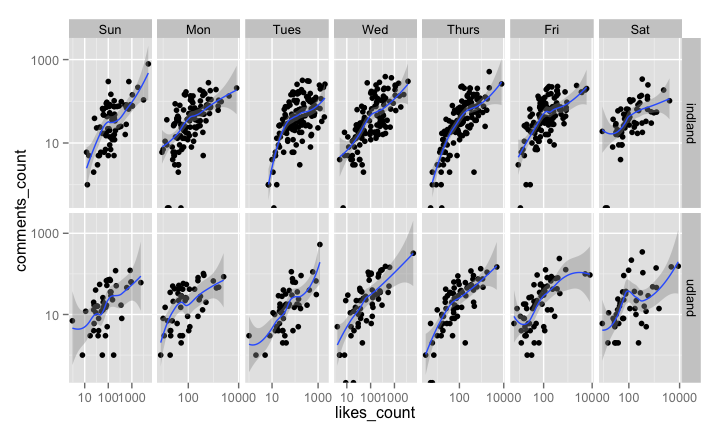

## Multiple scales

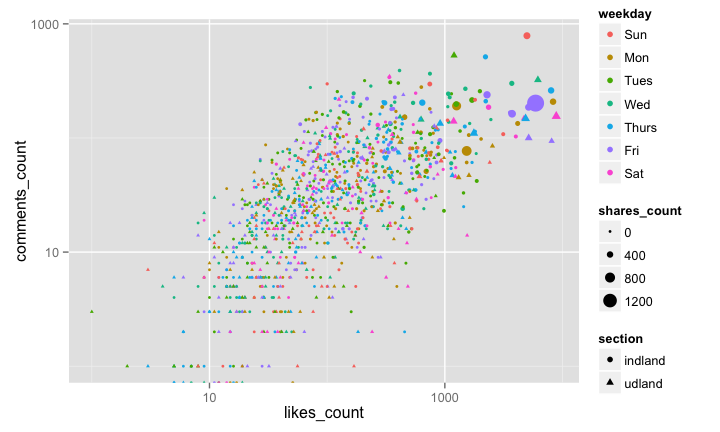

## Two categorical variables: tile plot

```r
tab = data.frame(table(df$section, df$weekday))
names(tab) = c("section", "weekday", "count")
```

Tile plot

```r
p = ggplot(tab, aes(x = section, y = weekday))
p = p + geom_tile(aes(fill = count))
```

## Result

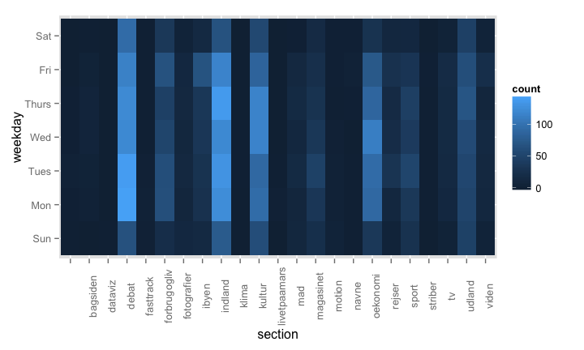

## Your turn

## Exercises

In the rest of the class, I want you to work together to try to reproduce the following plots

For getting help, I want you to learn how to use the ggplot2 webpage: http://ggplot2.org/

## Plot 1

Number of posts by section

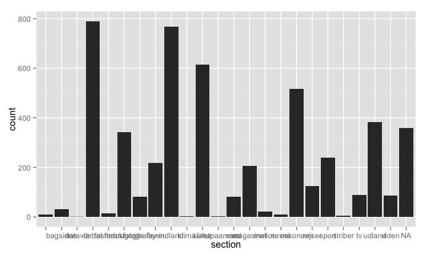

## Plot 2

`ggplot2` has several options to deal with overplotting. Take a look at the `alpha` argument to `geom_point` and try to reproduce the following plot

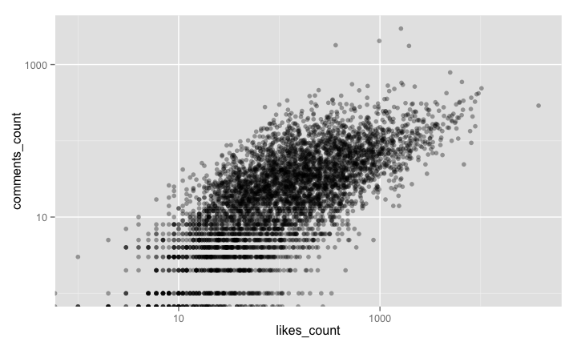

## Plot 3

Another option is to use hexagonal binning. Take a look at `geom_hex` and try to reproduce the following plot (you need to install the package `hexbin` from CRAN)

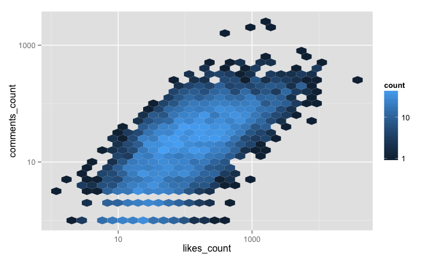

## Plot 4

You can customize titles using the `labs` argument. Use this function and try to reproduce the following

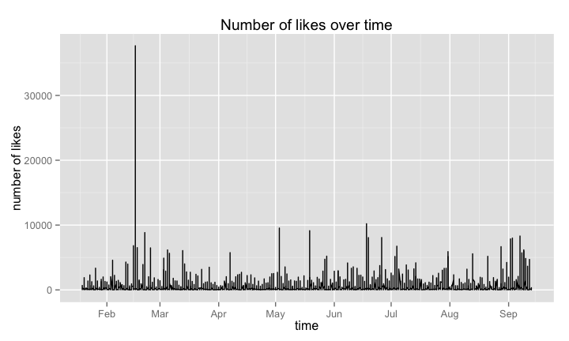

## Plot 5

You can control the baseline look of the plot using the `theme` function. Try to figure out what themes are available and reproduce the plot below

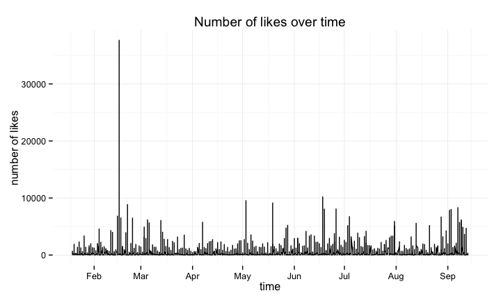

## Plot 6

`geom_rug` shows the marginal distribution of each of the plotting variable. Use this function to create the following plot

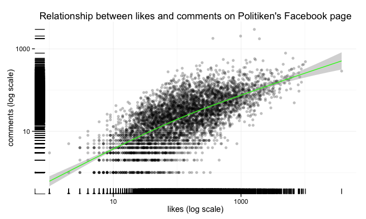

## Plot 7

Use what you know about categorical variables to produce the following graph

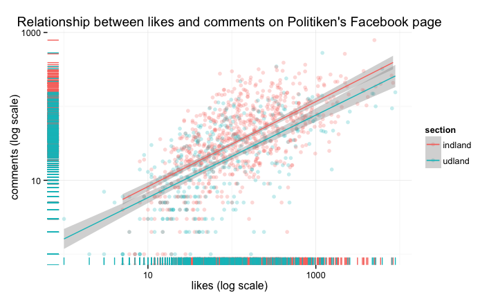

## Plot 8

At last, I want you to think of an graph that we haven't done yet and try to figure out how to produce it in `ggplot2`. This can, for example, be

- plot the number of likes by hour of the day Politiken posted the link
- plot the distribution of likes depending on the type of link posted
- is the relationship between likes and shares stronger for some sections than others?
- if time permits, read up on plotting geographical data using `ggplot2`